# Yerdle Take Home DS Exercise

Adam Gorski

### Load necessary packages, connect to data source, load data

```r
library(rJava)
library(RJDBC)
library(plyr)
library(dplyr)
library(pscl)
library(reshape2)
library(knitr)
library(rmarkdown)
```

```r
URL <- 'https://s3.amazonaws.com/athena-downloads/drivers/AthenaJDBC41-1.1.0.jar'
fil <- basename(URL)
if (!file.exists(fil)) download.file(URL, fil)
drv <- JDBC(driverClass="com.amazonaws.athena.jdbc.AthenaDriver", fil, identifier.quote="'")
con <- jdbcConnection <- dbConnect(drv, 'jdbc:awsathena://athena.us-west-1.amazonaws.com:443/',
                                   s3_staging_dir="s3://clusteryourself-home-projects.amazonaws.com",
                                   user=Sys.getenv("ATHENA_ACCESS_KEY_ID"),
                                   password=Sys.getenv("ATHENA_SECRET_ACCESS_KEY"))

setMethod("dbGetQuery", signature(conn="JDBCConnection", statement="character"),  def=function(conn, statement, ...) {
  r <- dbSendQuery(conn, statement, ...)
  on.exit(.jcall(r@stat, "V", "close"))
  if (conn@jc %instanceof% "com.amazonaws.athena.jdbc.AthenaConnection") fetch(r, -1, 999) # Athena can only pull 999 rows at a time
  else fetch(r, -1)
})

items <- dbGetQuery(con, "SELECT * FROM takehome.yerdle_item_data")
views <- dbGetQuery(con, "SELECT * FROM takehome.yerdle_pageviews")
```

### Initial data exploration

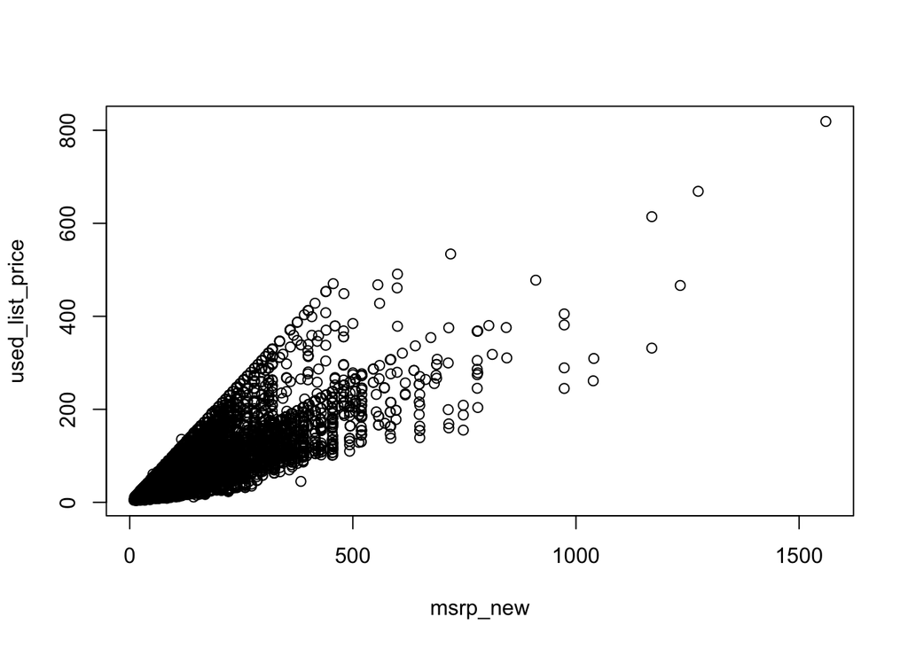

```r
plot(items$msrp_new, items$used_list_price, xlab = 'msrp_new', ylab = 'used_list_price')
```

```r
table(items$used_condition)
table(items$category)
table(items$department)
table(is.na(items$last_known_retail_price_new))/nrow(items)
table(items$first_ordered_date == '')/nrow(items)
```

[output not shown]

100% `OK` condition

23 categories: Appliances, Bags, etc.

7 departments: Furniture, Kitchen and Dining, etc.

45% of items were discounted while new

31% of items were not sold

### Formatting and modifying variables for modeling

```r
factor_vars <- c('used_condition', 'department', 'category', 'color')
for (i in 1:length(factor_vars)) {items[, factor_vars[i]] <- as.factor(items[, factor_vars[i]])}
items$first_ordered_date <- ifelse(items$first_ordered_date == '', NA, items$first_ordered_date)
items$first_approved_date <- as.Date(items$first_approved_date)
items$first_ordered_date <- as.Date(items$first_ordered_date)
```

I transform `used_condition`, `department`, `category`, and `color` into factor variables, and I modify some of the other variables.

```r
items$furniture_flg <- ifelse(items$department %in% c('Furniture', 'Kids Furniture', 'Outdoor Furniture'), 1, 0)
items$kids_flg <- ifelse(items$department %in% c('Kids Furniture', 'Kids Storage'), 1, 0)
items$outdoor_flg <- ifelse(items$department %in% c('Outdoor Furniture', 'Outdoor Storage'), 1, 0)
items$storage_flg <- ifelse(items$department %in% c('Kids Storage', 'Outdoor Storage', 'Storage'), 1, 0)
items$kitchen_flg <- ifelse(items$department == 'Kitchen and Dining', 1, 0)
```

For the `department` variable, I create flags for the overlapping departments.

```r
items$perc_msrp <- items$used_list_price/items$msrp_new
items$days_on_market <- items$first_ordered_date - items$first_approved_date
items$days_on_market <- ifelse(is.na(items$days_on_market), as.Date('2018-11-01') -
                                 items$first_approved_date, items$days_on_market)
items$sold <- ifelse(is.na(items$first_ordered_date), 0, 1)
items$discount <- ifelse(is.na(items$last_known_retail_price_new), 0, 1)
```

Here I create some new variables:

`perc_msrp` = % of MSRP of the used list price

`days_on_market` = number of days on market before sold; if not sold, number of days on market before max date of the dataset (2018/11/01)

`sold` = flag whether item was sold

`discount` = flag whether the item was offered at a discounted price while new.

```r
views$pp_scaled <- scale(views$pageviews)
items <- merge(items, views[, c('item_parent_sku', 'pp_scaled')], by = 'item_parent_sku', all.x = T)
```

I scaled the pageviews for the `item_parent_sku` and imported the scaled values into the `items` dataset.

### Estimate revenue function

```r
d <- 1
items$rev1 <- (1/((items$days_on_market/d) + 1)) * items$used_list_price * items$sold
```

Without no available storage cost information, I created a flexible relationship between revenue and inventory storage:

`rev1` = (1/((days_on_market/d) + 1)) * used_list_price * sold, `d` = 1

This function discounts the value of an item based on how long it takes to sell. When `d` = 1, an item is discounted by half on its second day in inventory compared to its first. Increasing `d` reduces an item’s discount rate, meaning its value depreciates more slowly as it spends time in inventory.

Below I estimate the model with `d` = 1, which will bias my results towards items that sell quickly.

### Define train, test, and validation sets

```r
sets <- data.frame(unique_item_id = unique(items$unique_item_id), rand = runif(length(unique(items$unique_item_id))))
sets$set <- ifelse(sets$rand < 0.7, 'train', ifelse(sets$rand >= 0.9, 'validation', 'test'))
items <- merge(items, sets[, c('unique_item_id', 'set')], by = 'unique_item_id')
```

Here I define train, test, and validation sets for model evaluation.

### Zero-inflated negative binomial regression for modeling risk

```r
rev1_zeroinfl <- zeroinfl(round(rev1*100) ~
                            perc_msrp + discount + pp_scaled + furniture_flg +
                            kids_flg + outdoor_flg + storage_flg
                          , data = items[items$set == 'train',]
                          , dist = 'negbin', EM = TRUE, na.action = na.omit)
```

`rev1` = 0 when the item is not sold, so the distribution is skewed right and has large number of `0` values. A zero-inflated negative binomial approach allows for the combination of modeling the probability of a `0` value and the predicted count. The model’s righthand side variables:

price: `perc_msrp`, `discount`

demand: `pp_scaled`

item type: `furniture_flg`, `kids_flg`, `outdoor_flg`, `storage_flg`

```r
summary(rev1_zeroinfl)
```

```
##
## Call:
## zeroinfl(formula = round(rev1 * 100) ~ perc_msrp + discount + pp_scaled +
##     furniture_flg + kids_flg + outdoor_flg + storage_flg, data = items[items$set ==
##     "train", ], na.action = na.omit, dist = "negbin", EM = TRUE)
##
## Pearson residuals:
##      Min       1Q   Median       3Q      Max
## -0.70175 -0.56136 -0.45409 -0.09117 28.65603
##
## Count model coefficients (negbin with log link):
##                Estimate Std. Error z value Pr(>|z|)
## (Intercept)    7.207212   0.050349 143.145  < 2e-16 ***
## perc_msrp      0.802682   0.063796  12.582  < 2e-16 ***
## discount      -0.217871   0.027874  -7.816 5.44e-15 ***
## pp_scaled      0.007687   0.003742   2.054     0.04 *
## furniture_flg -2.530666   0.106466 -23.770  < 2e-16 ***
## kids_flg       1.338011   0.106212  12.598  < 2e-16 ***
## outdoor_flg    0.946618   0.105593   8.965  < 2e-16 ***
## storage_flg   -2.031503   0.109257 -18.594  < 2e-16 ***
## Log(theta)    -0.523320   0.014268 -36.678  < 2e-16 ***
##
## Zero-inflation model coefficients (binomial with logit link):
##                Estimate Std. Error z value Pr(>|z|)
## (Intercept)   -1.710236   0.088021 -19.430  < 2e-16 ***
## perc_msrp      0.104502   0.101161   1.033    0.302
## discount      -0.318150   0.041895  -7.594 3.10e-14 ***
## pp_scaled     -0.004860   0.007254  -0.670    0.503
## furniture_flg  1.855995   0.136753  13.572  < 2e-16 ***
## kids_flg      -0.666047   0.130074  -5.121 3.05e-07 ***
## outdoor_flg   -0.052935   0.127412  -0.415    0.678
## storage_flg    1.088865   0.139450   7.808 5.80e-15 ***
## ---
## Signif. codes:  0 '***' 0.001 '**' 0.01 '*' 0.05 '.' 0.1 ' ' 1
##
## Theta = 0.5926
## Number of iterations in BFGS optimization: 1
## Log-likelihood: -8.291e+04 on 17 Df
```

### Model evaluation

```r
count_coef_mat <- t(as.data.frame(rev1_zeroinfl$coefficients$count))
train <- items$set == 'train' & complete.cases(items[, colnames(count_coef_mat)[2:length(colnames(count_coef_mat))]])
model_performance <- data.frame(pred = rev1_zeroinfl$fitted[train],
                                outcome_flg = items$sold[train],
                                outcome = items$rev1[train])
model_performance <- model_performance[!is.na(model_performance$pred),]
```

```r
model_thresh <- thresh_iter(0, 3000, 1, model_performance, 'pred', 'outcome_flg')
```

Note: model evalution `thresh_iter` function is internally developed

```r
model_thresh[which.max(model_thresh$f2),]
```

```
##    threshold  accuracy sensitivity specificity positive_pred_val
## 57        56 0.7407599           1           0         0.7407599
##    negative_pred_val false_positive_rate false_negative_rate
## 57               NaN                   1                   0
##    positive_likelihood_ratio negative_likelihood_ratio inverse_distance
## 57                         1                       NaN                0
##           f1       f2       fp5       auc
## 57 0.8510764 0.781267 0.9345855 0.5153939
```

Note: AUC and Accuracy will be slightly different in the text than the output. All model outputs change slightly every time `train` designation is reassigned, which occurs each time the file is converted to HTML.

### Model performance on test data

```r
test <- items$set == 'test' & complete.cases(items[, colnames(count_coef_mat)[2:length(colnames(count_coef_mat))]])
count_pred <- as.matrix(data.frame(Intercept = 1, items[test, colnames(count_coef_mat)[2:ncol(count_coef_mat)]]))

count_pred <- count_pred %*% rev1_zeroinfl$coefficients$count
zero_coef_mat <- t(as.data.frame(rev1_zeroinfl$coefficients$zero))
zero_pred <- as.matrix(data.frame(Intercept = 1, items[test, colnames(count_coef_mat)[2:ncol(count_coef_mat)]]))
zero_pred <- zero_pred %*% rev1_zeroinfl$coefficients$zero

pzero <- exp(zero_pred)/(1+exp(zero_pred))
pcount <- exp(count_pred)*(1-pzero)
items$pred_rev1[test] <- pcount/100

model_performance <- data.frame(pred = items$pred_rev1[test],
                                outcome_flg = items$sold[test],
                                outcome = items$rev1[test])
model_performance <- model_performance[!is.na(model_performance$pred),]
```

```r
model_thresh <- thresh_iter(0, 3000, 1, model_performance, 'pred', 'outcome_flg')
```

```r
model_thresh[which.max(model_thresh$f2),]
```

```
##   threshold  accuracy sensitivity specificity positive_pred_val
## 4         3 0.6755293   0.7825009   0.4317998         0.7583248
##   negative_pred_val false_positive_rate false_negative_rate
## 4         0.4656223           0.5682002           0.2174991
##   positive_likelihood_ratio negative_likelihood_ratio inverse_distance
## 4                  1.377157                 0.5037036        0.3915945
##          f1        f2       fp5       auc
## 4 0.7702232 0.7630397 0.7775431 0.6677055
```

Here I use the model parameters to calculate a classifer for the `test` dataset and evaluate the performance of the predicted value. On the test data, the model performs well. AUC = 0.68 and Accuracy = 0.69.

### Analyze for systematic underselling (in sold products)

```r
items$resid[items$sold == 1] <- items$pred_rev1[items$sold == 1] - items$rev1[items$sold == 1]

for (i in seq(from = floor(min(items$pp_scaled[test])),
              to = max(items$pp_scaled[test]), by = 2)) {
  if (i == floor(min(items$pp_scaled[test]))) {
    z <- test & items$pp_scaled > i & items$pp_scaled <= i + 2
    pp <- as.numeric(by(items$resid[z], items$department[z], function(x) {mean(x, na.rm = T)}))
    ct <- as.numeric(by(items$resid[z], items$department[z], length))
                  mat <- data.frame(min_pp_scaled = i, max_pp_scaled = i + 2, vws_mean = pp, ct = ct,
                                    department = levels(items$department))}
  else {
    z <- test & items$pp_scaled > i & items$pp_scaled <= i + 2
    pp <- as.numeric(by(items$resid[z], items$department[z], function(x) {mean(x, na.rm = T)}))
    ct <- as.numeric(by(items$resid[z], items$department[z], length))
        tmp <- data.frame(min_pp_scaled = i, max_pp_scaled = i + 2, vws_mean = pp, ct = ct, department = levels(items$department))
        mat <- rbind(mat, tmp)
  }}
mat <- mat[!is.na(mat$ct) & mat$ct > 30,]

dcast(mat, min_pp_scaled + max_pp_scaled ~ department, value.var = 'vws_mean')
```

```
##   min_pp_scaled max_pp_scaled  Furniture Kids Furniture Kids Storage
## 1            -1             1 -0.1947177     -0.6624062    -1.915454
## 2             1             3         NA     -2.1441384    -1.131488
## 3             3             5         NA             NA    -2.209920
## 4             5             7         NA             NA           NA
## 5             7             9         NA             NA           NA
## 6             9            11         NA             NA           NA
## 7            13            15         NA             NA           NA
## 8            17            19         NA             NA           NA
##   Kitchen and Dining Outdoor Furniture Outdoor Storage
## 1         -6.1942269         -1.959049       -1.213454
## 2         -9.8032306         -3.537000       -1.816337
## 3         -0.5102669         -2.810802       -5.995416
## 4        -18.1189998                NA       -2.121904
## 5        -12.0644947                NA              NA
## 6         13.2135912                NA              NA
## 7         13.1539043                NA              NA
## 8          5.1195711                NA              NA
```

Using the predicted values from the model, I examine whether there are systematic differences between predicted and actual values of the `rev1` function values for the `test` dataset. To incorporate dynamic demand, I evaluated the mean residuals across two dimensions: `department` and `pp_scaled` (scaled parent sku pageviews). Doing so produces something like a heatmap (above), where `Kitchen and Dining` items belonging to highly viewed (9+ standard deviations above mean) parent sku groups are systemically overvalued by the model. The overvaluation indicates that these items are not producing as much value as the model predicts. Therefore, I chose to start with these items for pricing recommendations.

### Pricing strategy improvement recommendation

Start with the sku groups in `Kitchen and Dining` where the pageviews are 9 or more standard deviations above the mean. These are generally items that sell for nearly 100% of MSRP but stay in inventory for a long period of time. Conduct A/B experiments where the price for the items in the treatment group decreases incrementally to see if turnover is improved compared to the control group. If so, consider dynamically aligning pageviews to price (% of MSRP) to further increase sales volume.

Keep in mind that the `rev1` function is biased towards selling products quickly. A different function with a decreased discount rate (1/`d`) will produce results more inclined towards revenue maximization rather than decreasing inventory storage. Further work would be needed to align this function with actual inventory costs.